# Stock Analysis and Prediction

## Abstract

My target audience for this dataset would be :- Investors, Competitors, Stock brokers and financial advisors. I have analyzed the growth and performance of top 5 and worst 5 performing companies. I have also analysed Bank of America's stock performance from Feb 2013 to Feb 2018 on the basis of below mentioned points:

Finding any trend, pattern or seasonality in its stock including any anomaly that may have occurred. I have tried exploring both the internal (C-level executives hiring/firing etc.) and external factors (market factors like recession, governmental regulations etc.) that led to the impact on the stock performance. This would help the target audience to check how much potential a stock has and whether that stock is worth investing on.

Comparing Bank of America's stock performance with that of Wells Fargo and exploring the same internal/external factors. This helps the companies and their competitiors to design their future strategies and time their product/service reveal. Moreover, it helps investors in deciding whether they should withdraw their shares from one company and invest in the other one instead.

Apart from that, I have applied a time series forecasting model i.e Facebook Prophet to predict the future performance of both the banks stocks on the basis of historical performance and other factors. This helps the financial advisors who can advise their customers on where they should invest their money.

```python
# Importing libraries

import numpy as np
import pandas as pd
import matplotlib.pyplot as plt
import seaborn as sns
import statsmodels.api as sm
%matplotlib inline
%pylab --no-import-all inline
sns.set_style("whitegrid")
from fbprophet import Prophet
from scipy import stats
from plotly import tools
import chart_studio.plotly as py
import plotly.figure_factory as ff
import plotly.tools as tls
import plotly.graph_objs as go
from plotly.offline import download_plotlyjs, init_notebook_mode, plot, iplot
init_notebook_mode(connected=True)

# Read the csv file
inputData = pd.read_csv('~/Desktop/Input/all_stocks_5yr.csv',parse_dates = ['date'])
inputData.head(10)
```

|  | date | open | high | low | close | volume | Name |
| --- | --- | --- | --- | --- | --- | --- | --- |
| 0 | 2013-02-08 | 15.07 | 15.12 | 14.63 | 14.75 | 8407500 | AAL |
| 1 | 2013-02-11 | 14.89 | 15.01 | 14.26 | 14.46 | 8882000 | AAL |
| 2 | 2013-02-12 | 14.45 | 14.51 | 14.10 | 14.27 | 8126000 | AAL |
| 3 | 2013-02-13 | 14.30 | 14.94 | 14.25 | 14.66 | 10259500 | AAL |
| 4 | 2013-02-14 | 14.94 | 14.96 | 13.16 | 13.99 | 31879900 | AAL |
| 5 | 2013-02-15 | 13.93 | 14.61 | 13.93 | 14.50 | 15628000 | AAL |
| 6 | 2013-02-19 | 14.33 | 14.56 | 14.08 | 14.26 | 11354400 | AAL |
| 7 | 2013-02-20 | 14.17 | 14.26 | 13.15 | 13.33 | 14725200 | AAL |
| 8 | 2013-02-21 | 13.62 | 13.95 | 12.90 | 13.37 | 11922100 | AAL |
| 9 | 2013-02-22 | 13.57 | 13.60 | 13.21 | 13.57 | 6071400 | AAL |

## Initial Data Analysis

```python
inputData.info()
```

```
<class 'pandas.core.frame.DataFrame'>
RangeIndex: 619040 entries, 0 to 619039
Data columns (total 7 columns):
date      619040 non-null datetime64[ns]
open      619029 non-null float64
high      619032 non-null float64
low       619032 non-null float64
close     619040 non-null float64
volume    619040 non-null int64
Name      619040 non-null object
dtypes: datetime64[ns](1), float64(4), int64(1), object(1)
memory usage: 33.1+ MB
```

```python
inputData.describe()
```

|  | open | high | low | close | volume |
| --- | --- | --- | --- | --- | --- |
| count | 619029.000000 | 619032.000000 | 619032.000000 | 619040.000000 | 6.190400e+05 |
| mean | 83.023334 | 83.778311 | 82.256096 | 83.043763 | 4.321823e+06 |
| std | 97.378769 | 98.207519 | 96.507421 | 97.389748 | 8.693610e+06 |
| min | 1.620000 | 1.690000 | 1.500000 | 1.590000 | 0.000000e+00 |
| 25% | 40.220000 | 40.620000 | 39.830000 | 40.245000 | 1.070320e+06 |
| 50% | 62.590000 | 63.150000 | 62.020000 | 62.620000 | 2.082094e+06 |
| 75% | 94.370000 | 95.180000 | 93.540000 | 94.410000 | 4.284509e+06 |
| max | 2044.000000 | 2067.990000 | 2035.110000 | 2049.000000 | 6.182376e+08 |

```python
# Missing Data Analysis : Check for null values. Get the sum of all the null rows
inputData.isnull().sum()
```

```
date       0
open      11
high       8
low        8
close      0
volume     0
Name       0
dtype: int64
```

```python
#drops rows with a null cell in the open column
updatedData=inputData.drop(inputData.loc[inputData['open'].isnull()].index)
# Check if there are still null values
updatedData.isnull().sum()
```

```
date      0
open      0
high      0
low       0
close     0
volume    0
Name      0
dtype: int64
```

```python
# Get the number of unique Names
updatedData['Name'].nunique()
```

```
505
```

```python
#First array returns the unique count of date and second array gives the count of unique days.
np.unique(np.unique(updatedData['Name'], return_counts = True)[1], return_counts = True)
```

```
(array([  44,  109,  142,  152,  215,  276,  297,  403,  463,  528,  561,
         581,  655,  661,  781,  850,  888,  917,  960,  975, 1063, 1169,
        1173, 1197, 1241, 1248, 1254, 1257, 1258, 1259]),
 array([  1,   1,   1,   1,   1,   1,   1,   1,   1,   1,   1,   2,   2,
          1,   1,   1,   1,   1,   1,   1,   1,   4,   1,   1,   2,   1,
          1,   2,   2, 468]))
```

```python
candidateIndexes = np.unique(updatedData['Name'], return_counts = True)[1] < 1259
indexesDropped = updatedData['Name'].isin(np.unique(updatedData['Name'])[candidateIndexes])
updatedData.drop(indexesDropped.index[indexesDropped], inplace = True)
```

```python
np.unique(np.unique(updatedData['Name'], return_counts = True)[1], return_counts = True)
```

```
(array([1259]), array([468]))
```

## Exploratory Data Analysis

### Growth of the company on each day based on the first day close price.

```python
# Fetching the closing price of each company for the first day i.e. 2013-02-08
name, close, date = updatedData[updatedData['date'] == updatedData['date'].min()][['Name', 'close', 'date']].T.values
# combining
closingPriceFirstDay = {n : c for n, c in zip(name, close)}
# Associate each name with the closing prices on first day
closingList = list(map(lambda x : closingPriceFirstDay[x], updatedData['Name'].values))
updatedData['Growth'] = updatedData['close'] / closingList
```

[output not shown]

```python
updatedData['Growth'].describe()
```

```
count    589212.000000
mean          1.469279
std           0.709789
min           0.078596
25%           1.086964
50%           1.304250
75%           1.651950
max          19.955538
Name: Growth, dtype: float64
```

```python
idx = 5
# Calculate last day growth for all companies
growthList = updatedData.loc[1258::1259][['date', 'Name', 'Growth']].sort_values('Growth')
print('Between 2013-02-08 and 2018-02-07, the following 5 companies saw the largest stock decline:')
display(growthList.head(idx))
print('Between 2013-02-08 and 2018-02-07, the following 5 companies saw the largest stock increase:')
display(growthList.tail(idx))
```

```
Between 2013-02-08 and 2018-02-07, the following 5 companies saw the largest stock decline:
```

|  | date | Name | Growth |
| --- | --- | --- | --- |
| 115559 | 2018-02-07 | CHK | 0.142857 |
| 494374 | 2018-02-07 | RRC | 0.181843 |
| 167637 | 2018-02-07 | DISCA | 0.323492 |
| 168896 | 2018-02-07 | DISCK | 0.339783 |
| 385161 | 2018-02-07 | MOS | 0.411238 |

```
Between 2013-02-08 and 2018-02-07, the following 5 companies saw the largest stock increase:
```

|  | date | Name | Growth |
| --- | --- | --- | --- |
| 524590 | 2018-02-07 | STZ | 6.723705 |
| 186846 | 2018-02-07 | EA | 7.084053 |
| 32733 | 2018-02-07 | ALGN | 7.159487 |
| 408783 | 2018-02-07 | NFLX | 10.233321 |
| 423891 | 2018-02-07 | NVDA | 18.496362 |

The above growth analysis can help financial as well as retirement advisors predict how well certain companies will be able to perform in the long run

```python
def plotGraph(data, namesList, titleList):
    for i in range(len(titleList)):
        matchedDataIdx = updatedData['Name'].isin(namesList[i])
        sub = updatedData[matchedDataIdx].groupby(['Name', 'date'])['Growth'].sum().reset_index()
        plt.figure(figsize(20, 10))
        sns.pointplot(x = 'date', y = 'Growth', hue = 'Name', data = sub, scale = 0.5)
        plt.title(titleList[i]  , size = 25)
        plt.legend(markerscale = 2, prop = {'size' : 15})
        plt.xlabel('Time', size = 20)
        plt.ylabel('Growth', size = 20)
        # We do not need any ticks on the x-axis
        plt.xticks([])
        plt.show()
```

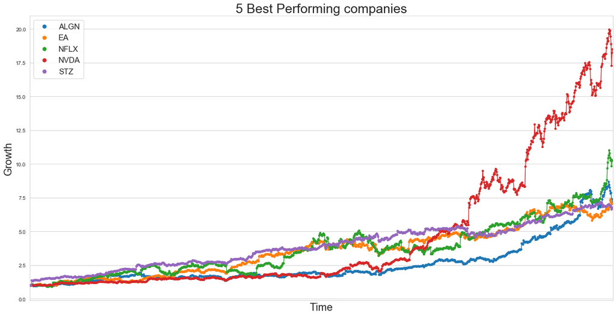

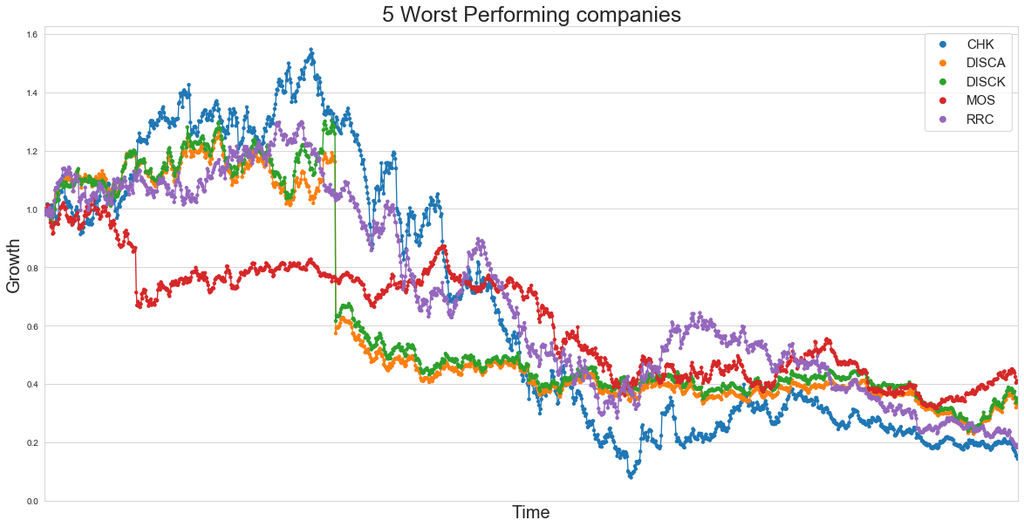

```python
worst_names = growthList.head(idx)['Name']
best_names = growthList.tail(idx)['Name']
namesList    = [best_names, worst_names]
chart_titles = ['5 Best Performing companies', '5 Worst Performing companies']
plotGraph(updatedData, namesList, chart_titles)
```

NVIDIA stock prices increased by almost 18 times as can be seen from the growth analysis. It's stocks showed a sharp rise in end of 2016 and 2017 because of it's presence in Gaming, Artificial Intelligence, Virtual Reality and NVDA's capability of building hardware for self-driving cars. Every single one of these areas is attractive to an investor who wants exposure to emerging technologies and moreover the scope of these areas in heavily growing. One more factor that led to rise in NVDA's stock prices is that the demand for pascal GPU's grew heavily in 2016 and the graphic cards were in short supply. Also, demand for their data centre's grew very much.

On the other hand, the worst performing stocks of Chesapeake Energy Corporation has been involved in a lot of controversies and lawsuits and that's why it's share prices dropped that much.

```python
# Correlation plot
def get_correlation(cor, upper = 0.99, lower = -0.99, blank = False):
    corr = {}
    for i in cor:
        obj = cor[i][cor[i].apply(abs).argsort()[::-1]]
        obj = obj[(obj > upper) | (obj < lower)]
        obj = obj[obj.index != i]
        if len(obj) == 0:
            if blank: corr[i] = None
        else:
            corr[i] = {}
            for j in obj.index:
                corr[i][j] = cor[i].loc[j]
    return corr
```

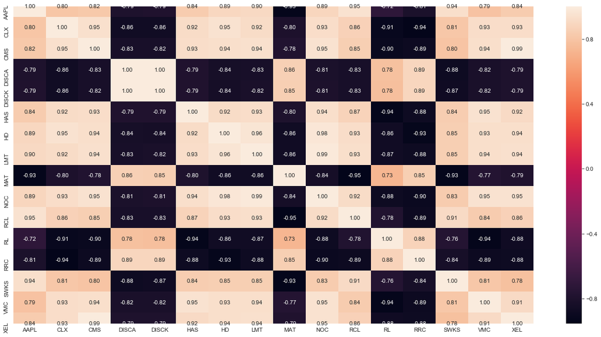

```python
cor = updatedData.pivot('date', 'Name', 'Growth').corr()
corr = get_correlation(cor, lower=-0.93)
sns.heatmap(cor.loc[list(corr), list((corr))], annot = True, fmt = '.2f')
plt.xlabel('')
plt.ylabel('')
plt.show()
```

### Comparison between Bank of America and Wells Fargo Stock Performance

```python
print('Bank of America and Wells Fargo had the following growth')
print(growthList.loc[growthList['Name'] == 'BAC'])
print(growthList.loc[growthList['Name'] == 'WFC'])
```

```
Bank of America and Wells Fargo had the following growth
            date Name    Growth
74128 2018-02-07  BAC  2.657313
             date Name    Growth
592669 2018-02-07  WFC  1.649656
```

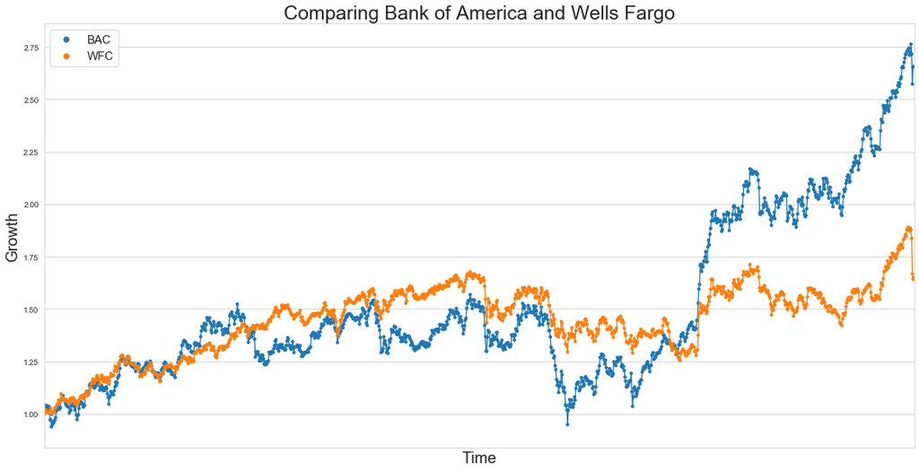

```python
namesList = [['BAC','WFC']]
chart_titles = ['Comparing Bank of America and Wells Fargo']
plotGraph(updatedData, namesList, chart_titles)
```

### Analysis and Forecasting of Bank of America Stocks

```python
bofaData = updatedData.loc[updatedData['Name'] == 'BAC']
wfData = updatedData.loc[updatedData['Name'] == 'WFC']
pd.concat([bofaData.reset_index().head(5), wfData.reset_index().head(5)],
          axis=1, keys=['BofA', 'Wells Fargo'])
```

|  | BofA index | BofA date | BofA open | BofA high | BofA low | BofA close | BofA volume | BofA Name | BofA Growth | Wells Fargo index | Wells Fargo date | Wells Fargo open | Wells Fargo high | Wells Fargo low | Wells Fargo close | Wells Fargo volume | Wells Fargo Name | Wells Fargo Growth |
| --- | --- | --- | --- | --- | --- | --- | --- | --- | --- | --- | --- | --- | --- | --- | --- | --- | --- | --- |
| 0 | 72870 | 2013-02-08 | 11.86 | 11.90 | 11.72 | 11.760 | 145217221 | BAC | 1.000000 | 591411 | 2013-02-08 | 34.69 | 34.915 | 34.68 | 34.88 | 18425772 | WFC | 1.000000 |
| 1 | 72871 | 2013-02-11 | 11.73 | 11.90 | 11.67 | 11.860 | 103499848 | BAC | 1.008503 | 591412 | 2013-02-11 | 34.95 | 35.390 | 34.92 | 35.26 | 24198800 | WFC | 1.010894 |
| 2 | 72872 | 2013-02-12 | 11.87 | 12.34 | 11.78 | 12.245 | 231771561 | BAC | 1.041241 | 591413 | 2013-02-12 | 35.33 | 35.550 | 35.22 | 35.51 | 19556611 | WFC | 1.018062 |
| 3 | 72873 | 2013-02-13 | 12.35 | 12.42 | 12.05 | 12.170 | 192478919 | BAC | 1.034864 | 591414 | 2013-02-13 | 35.45 | 35.520 | 34.95 | 35.13 | 21344989 | WFC | 1.007167 |
| 4 | 72874 | 2013-02-14 | 12.09 | 12.27 | 12.07 | 12.130 | 143901737 | BAC | 1.031463 | 591415 | 2013-02-14 | 35.02 | 35.270 | 34.91 | 35.21 | 22295663 | WFC | 1.009461 |

```python
# Prediction for Bank of America
bofa_predictor = Prophet(daily_seasonality=False)
# We are only interested in predicting the closing values
bofa_predicted_input = bofaData.drop(['open', 'high', 'low','volume', 'Name'], axis=1)
bofa_predicted_input.rename(columns={'close': 'y', 'date': 'ds'}, inplace=True)

bofa_predictor.fit(bofa_predicted_input)
```

```
<fbprophet.forecaster.Prophet at 0x1c31a73410>
```

```python
# Prediction for Wells Fargo
wf_predictor = Prophet(daily_seasonality=False)
# We are only interested in predicting the closing values
wf_predicted_input = wfData.drop(['open', 'high', 'low','volume', 'Name'], axis=1)
wf_predicted_input.rename(columns={'close': 'y', 'date': 'ds'}, inplace=True)

wf_predictor.fit(wf_predicted_input)
```

```
<fbprophet.forecaster.Prophet at 0x1c33bf8890>
```

```python
# Creating the data frame for the closing costs for the next 1 year
bofafutureClosingCosts = bofa_predictor.make_future_dataframe(periods=365)
# Predict the closing costs
bofaforecastedStockPrices = bofa_predictor.predict(bofafutureClosingCosts)
# Doing the same for Wells Fargo
wfFutureClosingCosts = wf_predictor.make_future_dataframe(periods=365)
wfForecastedStockPrices = wf_predictor.predict(wfFutureClosingCosts)
pd.concat([bofaforecastedStockPrices[['ds', 'yhat', 'yhat_lower', 'yhat_upper']].reset_index().tail(5),
           wfForecastedStockPrices[['ds', 'yhat', 'yhat_lower', 'yhat_upper']].reset_index().tail(5)],
          axis=1, keys=['BofA', 'Wells Fargo'])
```

|  | BofA index | BofA ds | BofA yhat | BofA yhat_lower | BofA yhat_upper | Wells Fargo index | Wells Fargo ds | Wells Fargo yhat | Wells Fargo yhat_lower | Wells Fargo yhat_upper |
| --- | --- | --- | --- | --- | --- | --- | --- | --- | --- | --- |
| 1619 | 1619 | 2019-02-03 | 38.331264 | 28.977533 | 48.354487 | 1619 | 2019-02-03 | 67.683989 | 53.646092 | 81.242383 |
| 1620 | 1620 | 2019-02-04 | 37.403929 | 27.800354 | 47.469999 | 1620 | 2019-02-04 | 66.247343 | 51.657978 | 79.349794 |
| 1621 | 1621 | 2019-02-05 | 37.429788 | 28.084834 | 47.395681 | 1621 | 2019-02-05 | 66.259043 | 52.588911 | 79.603982 |
| 1622 | 1622 | 2019-02-06 | 37.476967 | 27.857417 | 47.585767 | 1622 | 2019-02-06 | 66.290062 | 51.427214 | 79.813861 |
| 1623 | 1623 | 2019-02-07 | 37.476574 | 27.836373 | 47.459633 | 1623 | 2019-02-07 | 66.354758 | 52.060244 | 79.721760 |

```python
pd.concat([bofaData.reset_index().tail(5),
           wfData.reset_index().tail(5)], axis=1, keys=['BofA', 'Wells Fargo'])
```

|  | BofA index | BofA date | BofA open | BofA high | BofA low | BofA close | BofA volume | BofA Name | BofA Growth | Wells Fargo index | Wells Fargo date | Wells Fargo open | Wells Fargo high | Wells Fargo low | Wells Fargo close | Wells Fargo volume | Wells Fargo Name | Wells Fargo Growth |
| --- | --- | --- | --- | --- | --- | --- | --- | --- | --- | --- | --- | --- | --- | --- | --- | --- | --- | --- |
| 1254 | 74124 | 2018-02-01 | 32.00 | 32.50 | 31.96 | 32.50 | 62367448 | BAC | 2.763605 | 592665 | 2018-02-01 | 65.370 | 66.0900 | 65.06 | 65.51 | 15717623 | WFC | 1.878154 |
| 1255 | 74125 | 2018-02-02 | 32.44 | 32.67 | 31.86 | 31.95 | 96971924 | BAC | 2.716837 | 592666 | 2018-02-02 | 65.330 | 65.5254 | 63.83 | 64.07 | 18905283 | WFC | 1.836869 |
| 1256 | 74126 | 2018-02-05 | 31.12 | 31.98 | 29.15 | 30.26 | 155908256 | BAC | 2.573129 | 592667 | 2018-02-05 | 58.700 | 59.8900 | 57.50 | 58.16 | 103394442 | WFC | 1.667431 |
| 1257 | 74127 | 2018-02-06 | 29.41 | 31.29 | 29.30 | 31.20 | 165878399 | BAC | 2.653061 | 592668 | 2018-02-06 | 56.905 | 58.5000 | 55.87 | 57.28 | 83076895 | WFC | 1.642202 |
| 1258 | 74128 | 2018-02-07 | 31.12 | 31.74 | 30.86 | 31.25 | 101180515 | BAC | 2.657313 | 592669 | 2018-02-07 | 56.940 | 58.1150 | 56.75 | 57.54 | 45550954 | WFC | 1.649656 |

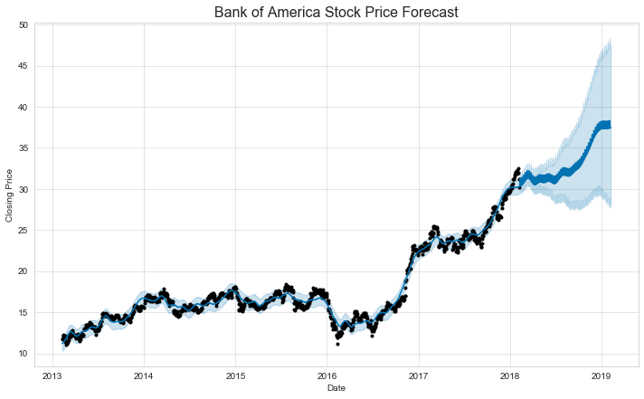

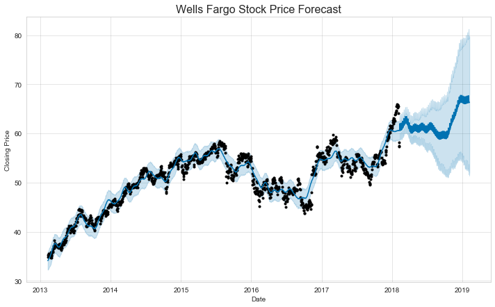

```python
bofaforecastPlt = bofa_predictor.plot(bofaforecastedStockPrices, xlabel='Date', ylabel='Closing Price')
# Prophet library automatically adds subplot. Get the first subplot and set its title
bofaAxis = bofaforecastPlt.get_axes()[0]
bofaAxis.set_title("Bank of America Stock Price Forecast", fontsize=16)

wfforecastPlt = wf_predictor.plot(wfForecastedStockPrices, xlabel='Date', ylabel='Closing Price')
# Prophet library automatically adds subplot. Get the first subplot and set its title
wfAxis = wfforecastPlt.get_axes()[0]
wfAxis.set_title("Wells Fargo Stock Price Forecast", fontsize=16)

plt.show()
```

Bank of America: When the new administration came post-elections in Jan 2017, they provided a pro-growth platform and promised to implement business friendly measures. For banks, this could eliminate some of the most onerous regulations of the 2010 Dodd-Frank Act and hence it could help in freeing banks up to increase lending and return more capital to shareholders. Moreover, the Federal Reserve consolidated the post-election gains in bank stocks by raising the fed funds rate, which is the key short-term interest rate benchmark in the United States. These factors combined with the recent rally in long-term interest rates, started adding additional revenue and profits each quarter for Bank of America.

Apart from that, bofa earned a profit of 7.3 billion dollars for the fourth quarter of 2018, which exceeded the expectations of all the investors and analysts. Marrill Edge (investment arm of bofa) brokerage assets grew by 5% i.e. 25b$ of net assests flowed into their accounts which indicated the excellent growth rate.

Wells Fargo: On the other hand, Wells Fargo was found associated with Account Fraud Scandal in late 2016, where they created millions of fraudulent savings and checking accounts on behalf of Wells Fargo clients without their consent. They also fired the whistleblower and many employees to generate fake accounts in 2017 and hence both customers and investors lost confidence and Wells Fargo stocks saw a lot of volatility.

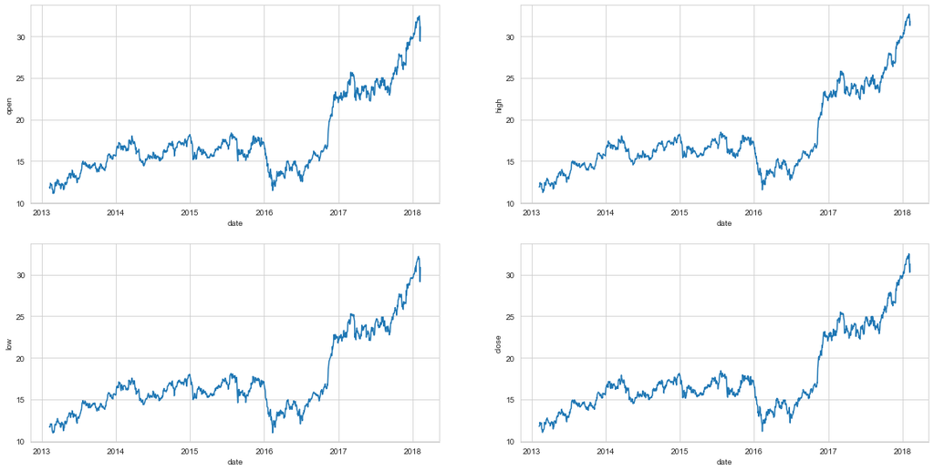

```python
#creating the subplots for each of the type
from pylab import rcParams
rcParams['figure.figsize'] = 20, 10
fig = plt.figure()
openPlot = fig.add_subplot(221)
openPlot = sns.lineplot(x="date", y="open",
                  markers=True, dashes=False, data=bofaData)
highPlot = fig.add_subplot(222, sharex=openPlot, sharey=openPlot)
highPlot = sns.lineplot(x="date", y="high",
                  markers=True, dashes=False, data=bofaData)
lowPlot = fig.add_subplot(223, sharex=openPlot, sharey=openPlot)
lowPlot = sns.lineplot(x="date", y="low",
                  markers=True, dashes=False, data=bofaData)
closedPlot = fig.add_subplot(224, sharex=openPlot, sharey=openPlot)
closedPlot = sns.lineplot(x="date", y="close",
                  markers=True, dashes=False, data=bofaData)
```

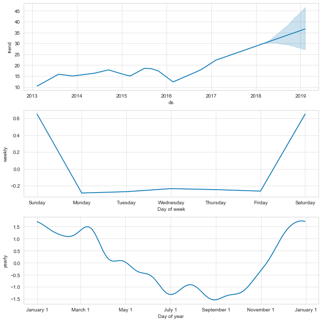

```python
forecastComponentsPlot = bofa_predictor.plot_components(bofaforecastedStockPrices)
plt.show()
```

Trends: The trend plot shows an increase in the BofA stock prices with time which is great.

Yearly Seasonality: BofA's stock price show upper trend signs during start and end of the year.

Weekly Seasonality: There is no weekly trend for stock price and the sharp decline in stock prices on Monday is due to the weekend effect.

```python
# Moving Averages (10, 50 and 200)
bofaData['10_d_avg'] = bofaData.close.rolling(window=10).mean()
bofaData['50_d_avg'] = bofaData.close.rolling(window=50).mean()
bofaData['200_d_avg'] = bofaData.close.rolling(window=200).mean()
updatedBofaData = bofaData.set_index('date')

fig = tls.make_subplots(rows=2, cols=1, shared_xaxes=True)

colors = ['#ff4500', '#92a1cf', '#6E6E6E']
avgs = ['10_d_avg', '50_d_avg', '200_d_avg']
# for i,c in zip(range(n),color):
#    ax1.plot(x, y,c=c)

for col, c in zip(avgs, colors):
    fig.append_trace({'x': updatedBofaData.index, 'y': updatedBofaData[col], 'type': 'scatter', 'name': col, 'line': {'color': c}}, 1, 1)
for col in ['close']:
    fig.append_trace({'x': updatedBofaData.index, 'y': updatedBofaData[col], 'type': 'scatter', 'name': 'Closing Price', 'line':{'color': '#01DF3A'}}, 2, 1)

fig['layout'].update(height=800,title='Relationship between Moving Average and Closing Price',
                    paper_bgcolor='#F2DFCE', plot_bgcolor='#F2DFCE')

iplot(fig, filename='pandas/mixed-type subplots')
```

[interactive chart not shown]

Moving Average is beneficial to analyze the stock performance in the longer time span because it smoothes out the fluctuations and volitility of the shorter intervals. And here therfore, 200 day moving average smmothes out a lot of spkies whereas a 10 day MA quite closely represents the actual closing price.

## Conclusion

So we can see that the above analysis will be helpful to investors and shareholders who wish to see the stock prediction of the company and decide whether the stock is worth investing or not.